# 7장 8장 과제

215083 박재석

2024-05-12

필요 라이브러리 불러오기

# 7.4 연습문제

## 4. 비구문적 이름을 참조하는 방법

```r
#데이터 준비
annoying <- tibble(
    `1` = 1:10,
    `2` = `1` * 2 + rnorm(length(`1`))
)
annoying
```

```
## # A tibble: 10 × 2
##      `1`   `2`
##    <int> <dbl>
##  1     1  3.48
##  2     2  4.93
##  3     3  6.22
##  4     4  8.34
##  5     5 11.0
##  6     6 11.1
##  7     7 13.0
##  8     8 16.1
##  9     9 18.0
## 10    10 19.7
```

#### a. 1이라는 이름의 변수 추출하기

```r
annoying$`1`
```

```
##  [1]  1  2  3  4  5  6  7  8  9 10
```

데이터프레임에서 비표준 이름을 가진 열을 추출할 때는 역따옴표 ` 를 사용하여 해당 열을 참조한다.

#### b. 1대 2의 산점도 플롯팅하기

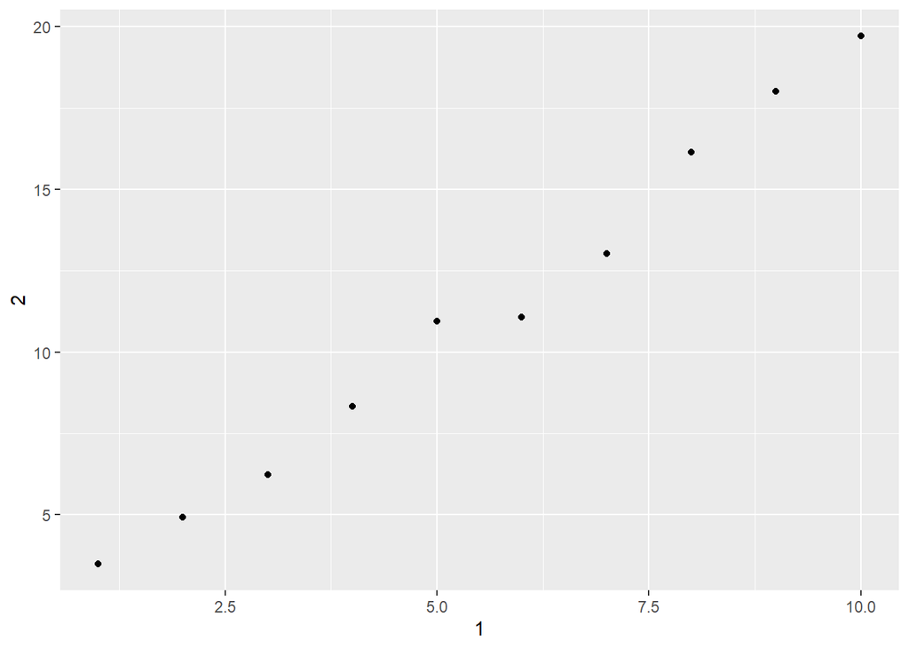

```r
ggplot(annoying, aes(x = `1`, y = `2`)) +
  geom_point()
```

ggplot2 라이브러리의 geom_ponit()를 사용하여 1 열과 2 열 간의 관계를 산점도로 나타냄.

#### c. 열 2를 열 1로 나누어 3이라는 새로운 열 생성

```r
annoying$`3` <- annoying$`2` / annoying$`1`
annoying
```

```
## # A tibble: 10 × 3
##      `1`   `2`   `3`
##    <int> <dbl> <dbl>
##  1     1  3.48  3.48
##  2     2  4.93  2.46
##  3     3  6.22  2.07
##  4     4  8.34  2.08
##  5     5 11.0   2.19
##  6     6 11.1   1.85
##  7     7 13.0   1.86
##  8     8 16.1   2.02
##  9     9 18.0   2.00
## 10    10 19.7   1.97
```

2 열을 1 열로 나누어 새로운 열 3을 생성함. ### d. 열의 이름을 one, two, three로 변경

```r
colnames(annoying) <- c("one", "two", "three")
annoying
```

```
## # A tibble: 10 × 3
##      one   two three
##    <int> <dbl> <dbl>
##  1     1  3.48  3.48
##  2     2  4.93  2.46
##  3     3  6.22  2.07
##  4     4  8.34  2.08
##  5     5 11.0   2.19
##  6     6 11.1   1.85
##  7     7 13.0   1.86
##  8     8 16.1   2.02
##  9     9 18.0   2.00
## 10    10 19.7   1.97
```

colnames 함수를 사용하여 데이터프레임의 열 이름을 변경함.

# 8.2 연습문제

## 5. 각 CSV의 문제 확인

#### 첫 번쩨

```r
read_csv("a,b\n1,2,3\n4,5,6")
```

```
## Warning: One or more parsing issues, call `problems()` on your data frame for details,
## e.g.:
##   dat <- vroom(...)
##   problems(dat)
```

```
## # A tibble: 2 × 2
##       a     b
##   <dbl> <dbl>
## 1     1    23
## 2     4    56
```

헤더에 두 개의 열(a, b)이 정의되어 있으나, 데이터 행에 세 개의 값이 있다. 열의 수가 일치하지 않아서 경고 메지와 함께 위와같이 자동으로 b에 값이 들어23, 56이 들어간다. #### 두 번째

```r
read_csv("a,b,c\n1,2\n1,2,3,4")
```

```
## Warning: One or more parsing issues, call `problems()` on your data frame for details,
## e.g.:
##   dat <- vroom(...)
##   problems(dat)
```

```
## # A tibble: 2 × 3
##       a     b     c
##   <dbl> <dbl> <dbl>
## 1     1     2    NA
## 2     1     2    34
```

첫 번째 데이터 행에 세 개의 열이 정의되었으나 두 개의 값만 제공되고, 두 번째 데이터 행에는 네 개의 값이 제공되고있다. 그래서 경고 메세지와 함께 첫번째 행의 c 에는 NA, 두번쨰 행에는 자동으로 34가 저장 된다.

#### 세 번째

```r
read_csv("a,b\n\1", na = ".")
```

```
## Warning: One or more parsing issues, call `problems()` on your data frame for details,
## e.g.:
##   dat <- vroom(...)
##   problems(dat)
```

```
## # A tibble: 1 × 2
##   a        b
##   <chr>    <lgl>
## 1 "\u0001" NA
```

데이터 행에서 백슬래시 사용이 문제가 되어 \001이 저장된다. 또한, na 옵션의 사용법이 적절하지 않다. 2개의 행에 하나의값만 제공되 경고메세지와 함께 b에는 NA가 저장된다.

#### 네 번째

```r
read_csv("a,b\n1,2\na,b")
```

```
## # A tibble: 2 × 2
##   a     b
##   <chr> <chr>
## 1 1     2
## 2 a     b
```

데이터의 타입이 일관되지 않아 1,2이 문자열로 저장된다.

#### 다섯 번째

```r
read_csv("a,b\n1;3")
```

```
## # A tibble: 1 × 2
##   a     b
##   <chr> <lgl>
## 1 1;3   NA
```

구분자가 쉼표가 아닌 세미콜론으로 사용되어있어 “1;3”을 문자로 인식하고, b에 들어갈 데이터가 없어 Na가 저장된다.

# 8.3 연습문제

## 7. 날짜와 시간 파싱

```r
# %B는 전체 월 이름을 나타내고, %d는 일(숫자), %Y는 4자리 연도를 나타냄.
d1 <- parse_date("January 1, 2010", format = "%B %d, %Y")
# %Y는 4자리 연도, %b는 축약된 월 이름, %d는 일을 나타냄.
d2 <- parse_date("2015-Mar-07", format = "%Y-%b-%d")
# %d는 일, %b는 축약된 월 이름, %Y는 4자리 연도를 나타냄.
d3 <- parse_date("06-Jun-2017", format = "%d-%b-%Y")
# %B로 월 이름을, %d로 일을, (%Y)로 괄호 안의 연도를 나타냄.
d4 <- parse_date(c("August 19 (2015)", "July 1 (2015)"), format = "%B %d (%Y)")
# %m은 2자리 월, %d는 2자리 일, %y는 2자리 연도를 나타냄.
d5 <- parse_date("12/30/14", format = "%m/%d/%y")
# %H는 24시간 형식의 시간을, %M은 분을 나타냄.
t1 <- parse_time("17:05", format = "%H:%M")
# %I는 12시간 형식의 시간, %M은 분, %OS는 초를 포함한 소수점을 나타내며, %p는 AM 또는 PM을 나타냄.
t2 <- parse_time("11:15:10.12 PM", format = "%I:%M:%OS %p")
#출력
print(d1)
```

```
## [1] "2010-01-01"
```

```r
print(d2)
```

```
## [1] "2015-03-07"
```

```r
print(d3)
```

```
## [1] "2017-06-06"
```

```r
print(d4)
```

```
## [1] "2015-08-19" "2015-07-01"
```

```r
print(d5)
```

```
## [1] "2014-12-30"
```

```r
print(t1)
```

```
## 17:05:00
```

```r
print(t2)
```

```
## 23:15:10.12
```